# SOCI 103M Final Project

Daniel Barquero and Belynda Herrera

24 March, 2023

# Section One: Introduction, Research Question, Background, and Hypothesis

Our research focuses on how the presence of hate groups in a state impacts hate crimes in Democratic vs. Republican states. Specifically, we examine whether the political voting habits of a state in presidential elections impacts the number of hate crimes in these states. It is important to note that for our research, we are not selecting any specific type of hate group or hate crime. We are encompassing all hate groups, as defined by the data from the Southern Poverty Law Center, and comparing it to all hate crimes from the data provided by the Department of Justice. We will be utilizing politics in this by establishing the political partisanship for each U.S. state and examining whether it impacts the presence of hate groups and the occurrence of hate crimes in states.

We chose to use political elections to separate the country as a basis for dividing the country into Democratic and Republican states. This division allowed for an analysis of trends in hate group formation and related hate crimes over time, highlighting the divergent patterns observed between regions with varying political affiliations.

This methodology of using political elections to divide the country was important as it allowed for a comparative analysis of patterns in hate group formation and related crimes over time concerning different political affiliations and their impact on the incidence of hate crimes over time. This approach enables researchers to gain a deeper understanding of the dynamics underlying hate crimes in America, enabling them to investigate how political affiliations might impact and shape hate group formation and hate crimes in the country. This type of analysis can inform policymaking and law enforcement strategies aimed at reducing the incidence of hate crimes in America, as it highlights which regions are most susceptible to hate group formation and related crimes. In conclusion, studying the prevalence and patterns of hate crimes across states with varying political affiliations provides important insights into the underlying dynamics that shape these incidents.

The null hypothesis for this research states that there is no correlation between a state’s political stance and the presence of hate groups/ the occurrence of hate crimes in states. We aim to investigate the correlation between political geography and hate crimes, with the objective of verifying the hypothesis that regions considered to be more liberal, such as California, are safer for marginalized communities, in comparison to areas known for being conservative, such as Alabama.

From a conflict theory perspective, this research can be seen as an attempt to understand how power dynamics between different groups of people contribute to the creation of an environment of fear and violence for some members of society. By looking into the relationship between political geography and hate crimes, we can gain a better understanding of how certain political ideologies can lead to certain patterns of hate-motivated violence, and what can be done to reduce those patterns. This research can also help to uncover the underlying mechanisms that lead to the perpetration of such hate-motivated violence, and how this can be addressed in order to create a more equitable and safe society for all.

This research question is important because it brings attention to trends for areas with high crime rates. It can help to raise awareness for hate crimes, as well as provide training for bystanders, police, and policy makers to prevent criminal activity and increase police presence in the states. It also provides the opportunity to study which areas need increased legislation to mitigate the frequency of hate crimes. This study will provide a broad overview of how certain states are affected by hate crime, and it serves to set the foundation for closer studies on a more local level.

This question is also of social, economic, and political importance. The phenomenon of hate-motivated violence is prevalent in many places around the world and has been the subject of extensive research. Other research has suggested conflicting results, as some studies have shown that more liberal areas tend to have lower hate crime rates, while others have found the opposite. Our research could potentially suggest something in opposition to established theories by uncovering the underlying mechanisms that lead to such violence and how this can be addressed in order to create a more equitable and safe society for all.

Hate crimes continue to be a pervasive and unsettling issue throughout the United States, with marginalized communities bearing the brunt of their devastating impact. The presidential election in 2000 saw a greater number of states voting Republican than Democrat, with Democratic-leaning states recording fewer instances of hate groups but higher crime rates - most notably California which reported an alarming 1943 hate crimes. Conversely, Republican-leaning states showed evidence of more active hate groups but lower incidence of hate-related offenses overall. While it may seem from this data that living in a republican state would offer greater safety against these appalling acts, such correlations are far from conclusive proof. Causation is not necessarily linked to political geography alone; comprehensive research must therefore be conducted before making any definitive conclusions about how this factor relates to patterns in incidents involving hatred or discrimination.

In the field of sociology, the causes and effects of violence against marginalized communities have been diligently studied in a plethora of journals, dissertations, and research papers. Our research will look to add on to the work in this field, and provide insightful answers to the questions at hand.

# Section Two: Literature Review

The article “Making Hate History” explores the work of the New York City Police Department (NYPD) dedicated to eradicating hate crime in New York City. The data collected in this paper shows that an increased passing of legislation, coupled with increased funding to its Hate Crime Task Force, has led to a reduced number of hate crimes in New York City. The methods used in this paper are simple statistics, mainly charts depicting the number of hate crimes per year in a time series. The groups examined are African-Americans, LGBTQ+ identifying individuals, and Jews.

While our research does not employ the split-group theory employed in this paper, we do analyze the impacts of a decrease in violence through our theory. Specifically, democratic states, such as New York are traditionally more open to spending money on large-scale government social programs. Our data will see whether these states do indeed see a drop in the occurrence of hate crimes, or if external factors should also be examined.

Since this data was collected just for New York City, our independent research can contribute to this pre-built research by examining the thesis on a larger scale. Since our data focuses on a state level, applied across the nation, we can see whether the decrease of hate crimes through increased legislation is applicable on a more holistic scale. Our research will serve as a test to see how extendable the conclusions of this prior research are.

The article “White supremacist groups and hate crime” focuses on the increase in hate-based violence in an area when multiple white supremacist organizations are in the area. The null hypothesis for this paper states that white supremacist groups form in response to anti-white based crimes. Additionally, this paper seeks to debunk the theory that hate groups form to create a safe space for individuals to vent racial frustrations and turn away from violent acts. This article uses data from the Southern Poverty Law Center to prove its four hypotheses. The first of these four hypotheses states that white supremacy activity is associated with higher crime rates. The second of these hypotheses states that white supremacy is symptomatic of the overall level of biased-based violence. The third hypothesis states that white supremacist groups form in response to anti-white hate crime. The final hypothesis states that white supremacist groups are correlated with some idiosyncratic factor that influences hate crimes.

While we are not focusing solely on pro-white supremacy groups, we are especially interested in utilizing this paper because it utilizes data from the Southern Poverty Law Center, and FBI’s annual Hate Crime Statistics Report. The Southern Poverty Law Center data is data which we are also utilizing for our independent research. Our research will build upon the theoretical foundations of this paper by examining the hypotheses presented in this paper. Specifically, this paper argues for an increase in hate-based violence in areas where multiple hate groups are present. Since our data groups hate groups by area, we will be looking to see if areas with a plethora of hate crimes experience more hate crimes than areas with fewer or none hate groups.

In terms of expanding upon this research, we will be furthering this research by either agreeing with its hypothesis through our findings, or potentially challenging its results through our own findings. If we come to the conclusion that the number of hate groups in an area does not definitively impact the occurrence of hate crimes in that area, then we would be arguing against the conclusions of this paper. This will be especially interesting to see considering that both our research and this source are using data from the Southern Poverty Law Center.

The article “Community (Dis)Organization and Racially Motivated Crime” examines the relationship between community structural conditions and racially motivated crimes against blacks and whites. Centering on the Chicago, Illinois area, this paper focuses on the social organization of racial hate crimes derived from social disorganization. The methods used in this paper focus on multivariate analysis with controls for spacial autocorrelation. The results of the study show that anti-black hate crimes, in contrast to general forms of crime, are more likely in relatively organized communities with high levels of informal social control. On the contrary, anti-white incidents appear more numerous in traditionally disorganized communities, especially those characterized by residential instability.

Similar to the “Making Hate History” article which focused on hate crime in New York City, this article utilizes the Chicago area as a study for its analysis. As with the “Making Hate History” article, our research will utilize the conclusions seen here on a local scale, and determine whether these conclusions can be applied to a larger national scale. While the “Making Hate History” article focused on legislation towards combating hate crime, this article focuses more on the impacts of social organization and disorganization on hate crime. For our study, considering that Chicago is another primarily liberal area, we will look to see if the crime trends in our democratic states show an increase. Should that be the case, this literature could help explain the trend.

In terms of furthering this research, we can draw parallels between our conclusions and the conclusions of this research. Since this research analyzes the societal characteristics of communities to draw conclusions on the linkage with hate crime, we can also make similar observations in the states we study. Specifically, we can examine commonalities within the trends described here and the wider conclusions created by our study.

The article “Hate Groups and Muslim Population Changes in the Fifty States: Does the Presence of Muslims Encourage Hate Group Formation?” focuses on social dominance theory and group hate theory to determine whether there is a correlation between the size of a Muslim population and the number of hate groups in that area. The article uses a paneled negative binomial regression with a number of relevant control variables to determine that the relationship between these two variables is not statistically significant. The article goes on to unpack the research and discuss the conclusions.

One interesting find in this paper is that the relationship between the size of a Muslim population and the number of hate groups present is not statistically significant. This will be important for our work as we determine whether political voter behavior of a state is statistically significant in comparison to hate groups. If the answer is no, we can look to the conclusions of this paper to help explain why we might be seeing what we are seeing in the data.

In terms of furthering this research, we cannot directly further it because we are not looking at an independent view of each type of hate group and hate crime. What we can do is use the conclusions of this piece as external scholastic information for why we are seeing what we are seeing.

The article “The Determinants of the Number of White Supremacist Groups: A Pooled Time-Series Analysis” examines the political and social mechanisms which explain and promote the growth of white supremacist groups in the United States.This paper uses pooled time-series cross-sectional methods to assess the explanatory power of three racial threat accounts. First, since lynchings indicated intense animosity against blacks that may persist, anti-black hate groups should be especially numerous where lynching rates were substantial in the distant past. Second, where or when white political and cultural dominance is threatened by large or growing black populations, additional white supremacist groups should be present. Third, these anti-black movements often recruit by emphasizing the links between race and violent street crime. This paper further examines stereotypes made by the public. For example, this paper examines the idea that areas where black violence towards whites is high should produce an increase in Anti-Black hate groups. The ultimate goal of this paper is to examine the factors, both political and social, which contribute to the growth of the number of white supremacist groups in an area.

Focusing on our research, we are looking for the linkages between the presence of hate groups in an area, on a national scale, and the corresponding rate of hate crimes in that area. This paper works perfectly as a foundation for that analysis by discussing both the legislative and social reasons for why we might expect to see larger numbers of hate groups in certain areas while seeing smaller numbers in other groups. This understanding will help us unpack our conclusions as to if/how certain legislation can be used to mitigate hate crimes across the nation.

In terms of furthering this research, our research will provide either confirmation or negation of the claims made in this work. While this work serves as a theoretical springboard for our research, we can also use it to draw conclusions about why certain areas have more white supremacist groups than others. Depending on what our research shows, we can use the conclusions to either validate or negate the claims made by this article.

# Works Cited Page: In order of appearance above

1. Levin, Brian, and Sara-Ellen Amster. “Making Hate History: Hate Crime and Policing in America … - Sage Journals.” Sage Journals, 27 July 2016, https://journals.sagepub.com/doi/10.1177/0002764207306062.
2. Mulholland, Sean E. “White Supremacist Groups and Hate Crime.” Public Choice, vol. 157, no. 1/2, 2013, pp. 91–113. JSTOR, http://www.jstor.org/stable/42003194. Accessed 20 Feb. 2023.
3. Lyons, Christopher J. “Community (Dis)Organization and Racially Motivated Crime.” American Journal of Sociology, vol. 113, no. 3, 2007, pp. 815–63. JSTOR, https://doi.org/10.1086/521846. Accessed 20 Feb. 2023.
4. Hummel, Daniel. “Hate Groups and Muslim Population Changes in the Fifty States: Does the Presence of Muslims Encourage Hate Group Formation?” International Journal on Minority and Group Rights, vol. 25, no. 2, 2018, pp. 317–32. JSTOR, https://www.jstor.org/stable/26557897. Accessed 20 Feb. 2023.
5. Rachel M. Durso, and David Jacobs. “The Determinants of the Number of White Supremacist Groups: A Pooled Time-Series Analysis.” Social Problems, vol. 60, no. 1, 2013, pp. 128–44. JSTOR, https://doi.org/10.1525/sp.2013.60.1.128. Accessed 20 Feb. 2023.

# Section Three: Data and Methods

# Section Four: Data Results

**Step One: Load the required packages**

**Step Two: Load in the hatecrimes dataset**

```
##     State.Name X2000Crime X2001Crime X2002Crime X2003Crime X2004Crime
## 1      Alabama         NA          0          2          1          3
## 2       Alaska          4         20          7         13          9
## 3      Arizona        240        384        238        246        224
## 4     Arkansas          3          3          0        170         93
## 5   California       1943       2246       1648       1472       1393
## 6     Colorado        101        126         96         82         59
## 7  Connecticut        151        169        129        134        116
## 8     Delaware         34         17         13         17         33
## 9      Florida        240        302        257        231        274
## 10     Georgia         35         39         31         23         29
##    X2005Crime X2006Crime X2007Crime X2008Crime X2009Crime X2010Crime X2011Crime
## 1           0          1          6         11          9         19         83
## 2           4          6          8          8          9          7          8
## 3         138        149        161        185        219        236        192
```

[output cut: 73 more lines]

**Step Three: Linear Regression with state political voting preferences in presidential elections as the predictors and the number of hate crimes across all states as the dependent variables.**

```
##
## Call:
## lm(formula = X2000Crime + X2001Crime + X2002Crime + X2003Crime +
##     X2004Crime + X2005Crime + X2006Crime + X2007Crime + X2008Crime +
##     X2009Crime + X2010Crime + X2011Crime + X2012Crime + X2013Crime +
##     X2014Crime + X2015Crime + X2016Crime + X2017Crime + X2018Crime +
##     X2019Crime + X2020Crime ~ Rep2000 + Dem2000 + Rep2004 + Dem2004 +
##     Rep2008 + Dem2008 + Rep2012 + Dem2012 + Rep2016 + Dem.2016 +
##     Rep2020 + Dem2020, data = hatecrimes)
##
## Residuals:
##     Min      1Q  Median      3Q     Max
## -4456.9 -1994.0  -704.8   466.9 21370.7
##
## Coefficients: (5 not defined because of singularities)
##             Estimate Std. Error t value Pr(>|t|)
## (Intercept)  11823.0     4316.4   2.739  0.00916 **
## Rep2000        296.6     2818.5   0.105  0.91672
## Dem2000           NA         NA      NA       NA
## Rep2004      -2048.9     2893.2  -0.708  0.48295
## Dem2004           NA         NA      NA       NA
## Rep2008       -520.2     3203.6  -0.162  0.87181
## Dem2008           NA         NA      NA       NA
## Rep2012      -8062.8     5995.6  -1.345  0.18627
## Dem2012      -7096.7     4465.6  -1.589  0.11989
## Rep2016        102.5     2367.3   0.043  0.96567
## Dem.2016          NA         NA      NA       NA
## Rep2020       -139.5     2569.7  -0.054  0.95697
## Dem2020           NA         NA      NA       NA
## ---
## Signif. codes:  0 '***' 0.001 '**' 0.01 '*' 0.05 '.' 0.1 ' ' 1
##
## Residual standard error: 4316 on 40 degrees of freedom
##   (2 observations deleted due to missingness)
## Multiple R-squared:  0.1966, Adjusted R-squared:  0.05602
## F-statistic: 1.398 on 7 and 40 DF,  p-value: 0.2329
```

**Step Four: Linear Regression with state political voting preferences in presidential elections as the predictors and the number of hate groups across all states as the dependent variables.**

```
##
## Call:
## lm(formula = X2000Group + X2001Group + X2002Group + X2003Group +
##     X2004Group + X2005Group + X2006Group + X2007Group + X2008Group +
##     X2009Group + X2010Group + X2011Group + X2012Group + X2013Group +
##     X2014Group + X2015Group + X2016Group + X2017Group + X2018Group +
##     X2019Group + X2020Group ~ Rep2000 + Dem2000 + Rep2004 + Dem2004 +
##     Rep2008 + Dem2008 + Rep2012 + Dem2012 + Rep2016 + Dem.2016 +
##     Rep2020 + Dem2020, data = hatecrimes)
##
## Residuals:
##     Min      1Q  Median      3Q     Max
## -397.50 -209.57  -73.06  132.18 1128.97
##
## Coefficients: (5 not defined because of singularities)
##             Estimate Std. Error t value Pr(>|t|)
## (Intercept)   695.00     320.72   2.167   0.0360 *
## Rep2000       249.47     209.21   1.192   0.2398
## Dem2000           NA         NA      NA       NA
## Rep2004       -67.85     214.66  -0.316   0.7535
## Dem2004           NA         NA      NA       NA
## Rep2008      -185.24     237.50  -0.780   0.4398
## Dem2008           NA         NA      NA       NA
## Rep2012      -546.76     444.49  -1.230   0.2255
## Dem2012      -452.97     331.09  -1.368   0.1786
## Rep2016       316.34     175.02   1.807   0.0779 .
## Dem.2016          NA         NA      NA       NA
## Rep2020      -127.19     190.48  -0.668   0.5080
## Dem2020           NA         NA      NA       NA
## ---
## Signif. codes:  0 '***' 0.001 '**' 0.01 '*' 0.05 '.' 0.1 ' ' 1
##
## Residual standard error: 320.7 on 42 degrees of freedom
## Multiple R-squared:  0.1397, Adjusted R-squared:  -0.003696
## F-statistic: 0.9742 on 7 and 42 DF,  p-value: 0.4625
```

**Step Five: Linear Regression with the number of hate groups across all states as the predictors and the number of hate crimes across all states as the dependent variables.**

```
##
## Call:
## lm(formula = X2000Crime + X2001Crime + X2002Crime + X2003Crime +
##     X2004Crime + X2005Crime + X2006Crime + X2007Crime + X2008Crime +
##     X2009Crime + X2010Crime + X2011Crime + X2012Crime + X2013Crime +
##     X2014Crime + X2015Crime + X2016Crime + X2017Crime + X2018Crime +
##     X2019Crime + X2020Crime ~ X2000Group + X2001Group + X2002Group +
##     X2003Group + X2004Group + X2005Group + X2006Group + X2007Group +
##     X2008Group + X2009Group + X2010Group + X2011Group + X2012Group +
##     X2013Group + X2014Group + X2015Group + X2016Group + X2017Group +
##     X2018Group + X2019Group + X2020Group, data = hatecrimes)
##
## Residuals:
##     Min      1Q  Median      3Q     Max
## -2780.4 -1044.4  -109.7   901.1  4654.3
##
## Coefficients:
##             Estimate Std. Error t value Pr(>|t|)
## (Intercept)  -86.432    584.402  -0.148   0.8836
## X2000Group  -376.545    177.365  -2.123   0.0434 *
## X2001Group  -119.331    161.217  -0.740   0.4658
## X2002Group   191.348    167.184   1.145   0.2628
## X2003Group    42.056    184.681   0.228   0.8216
## X2004Group    23.414    346.026   0.068   0.9466
## X2005Group  -107.481    316.980  -0.339   0.7373
## X2006Group  -147.637    265.998  -0.555   0.5836
## X2007Group   275.028    209.497   1.313   0.2007
## X2008Group  -130.582    198.067  -0.659   0.5155
## X2009Group   -34.196    113.397  -0.302   0.7654
## X2010Group   173.054    135.601   1.276   0.2132
## X2011Group  -158.556    109.346  -1.450   0.1590
## X2012Group   217.853    150.617   1.446   0.1600
## X2013Group    -3.898    206.568  -0.019   0.9851
## X2014Group   173.168    184.871   0.937   0.3575
## X2015Group  -237.130     94.748  -2.503   0.0189 *
## X2016Group   164.464    153.866   1.069   0.2949
## X2017Group  -246.795    171.118  -1.442   0.1612
## X2018Group   191.535    202.459   0.946   0.3528
## X2019Group   411.620    200.102   2.057   0.0498 *
## X2020Group  -308.696    165.065  -1.870   0.0728 .
## ---
## Signif. codes:  0 '***' 0.001 '**' 0.01 '*' 0.05 '.' 0.1 ' ' 1
##
## Residual standard error: 2108 on 26 degrees of freedom
##   (2 observations deleted due to missingness)
## Multiple R-squared:  0.8754, Adjusted R-squared:  0.7748
## F-statistic:   8.7 on 21 and 26 DF,  p-value: 4.127e-07
```

**First Data Visualization: Line Plots**

**In order to accomplish these visualizations, we first divided up the states. Specifically, we created 12 new dataframes based on how states voted in presidential elections (Republican or Democrat). These results start with the 2000 presidential election and go until the 2020 presidential election.**

**Lineplot showing the relationship between hate groups and hate crimes for states that voted Republican in 2000.**

```
##  [1] "Alabama"        "Alaska"         "Arizona"        "Arkansas"
##  [5] "Colorado"       "Florida"        "Georgia"        "Idaho"
##  [9] "Indiana"        "Kansas"         "Kentucky"       "Louisiana"
## [13] "Mississippi"    "Missouri"       "Montana"        "Nebraska"
## [17] "Nevada"         "New Hampshire"  "North Carolina" "North Dakota"
## [21] "Ohio"           "Oklahoma"       "South Carolina" "South Dakota"
## [25] "Tennessee"      "Texas"          "Utah"           "Virginia"
## [29] "West Virginia"  "Wyoming"
```

**Lineplot showing the relationship between hate groups and hate crimes for states that voted Democrat in 2000.**

```
##  [1] "California"    "Connecticut"   "Delaware"      "Hawaii"
##  [5] "Illinois"      "Iowa"          "Maine"         "Maryland"
##  [9] "Massachusetts" "Michigan"      "Minnesota"     "New Jersey"
## [13] "New Mexico"    "New York"      "Oregon"        "Pennsylvania"
## [17] "Rhode Island"  "Vermont"       "Washington"    "Wisconsin"
```

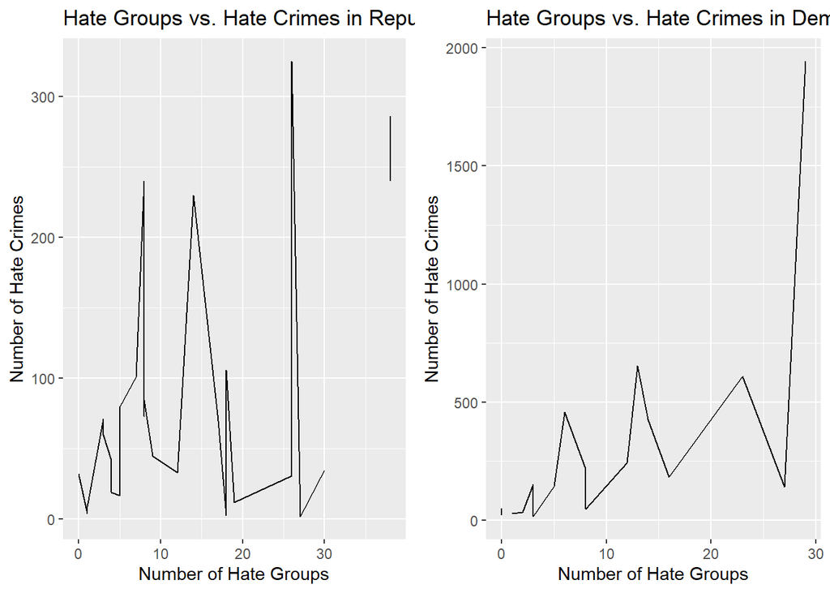

The presidential election in 2000 saw a greater number of states voting Republican than Democrat, with Democratic-leaning states recording fewer instances of hate groups but higher crime rates - most notably California which reported an alarming 1943 hate crimes. Conversely, Republican-leaning states showed evidence of more active hate groups but a lower incidence of hate-related offenses overall.

**Lineplot showing the relationship between hate groups and hate crimes for states that voted Republican in 2004.**

```
##  [1] "Alabama"        "Alaska"         "Arizona"        "Arkansas"
##  [5] "Colorado"       "Florida"        "Georgia"        "Idaho"
##  [9] "Indiana"        "Iowa"           "Kansas"         "Kentucky"
## [13] "Louisiana"      "Mississippi"    "Missouri"       "Montana"
## [17] "Nebraska"       "Nevada"         "New Mexico"     "North Carolina"
## [21] "North Dakota"   "Ohio"           "Oklahoma"       "South Carolina"
## [25] "South Dakota"   "Tennessee"      "Texas"          "Utah"
## [29] "Virginia"       "West Virginia"  "Wyoming"
```

**Lineplot showing the relationship between hate groups and hate crimes for states that voted Democrat in 2004.**

```
##  [1] "California"    "Connecticut"   "Delaware"      "Hawaii"
##  [5] "Illinois"      "Maine"         "Maryland"      "Massachusetts"
##  [9] "Michigan"      "Minnesota"     "New Hampshire" "New Jersey"
## [13] "New York"      "Oregon"        "Pennsylvania"  "Rhode Island"
## [17] "Vermont"       "Washington"    "Wisconsin"
```

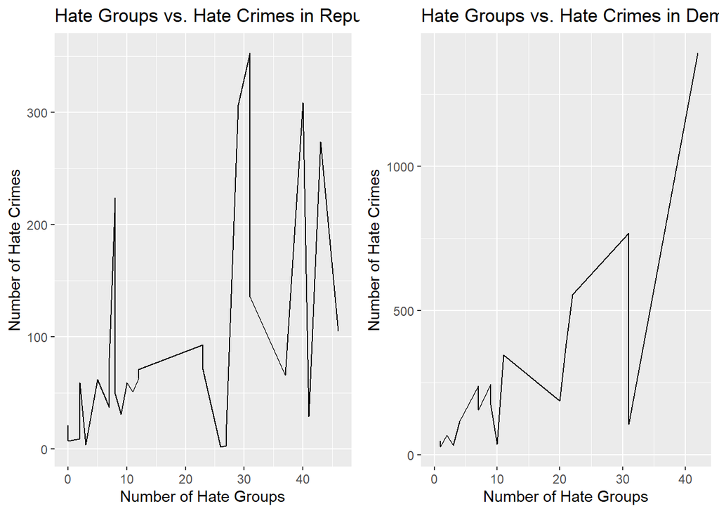

**Lineplot showing the relationship between hate groups and hate crimes for states that voted Republican in 2008.**

```
##  [1] "Alabama"        "Alaska"         "Arizona"        "Arkansas"
##  [5] "Georgia"        "Idaho"          "Kansas"         "Kentucky"
##  [9] "Louisiana"      "Mississippi"    "Missouri"       "Montana"
## [13] "Nebraska"       "North Dakota"   "Oklahoma"       "South Carolina"
## [17] "South Dakota"   "Tennessee"      "Texas"          "Utah"
## [21] "West Virginia"  "Wyoming"
```

**Lineplot showing the relationship between hate groups and hate crimes for states that voted Democrat in 2008.**

```
##  [1] "California"     "Colorado"       "Connecticut"    "Delaware"
##  [5] "Florida"        "Hawaii"         "Illinois"       "Indiana"
##  [9] "Iowa"           "Maine"          "Maryland"       "Massachusetts"
## [13] "Michigan"       "Minnesota"      "Nevada"         "New Hampshire"
## [17] "New Jersey"     "New Mexico"     "New York"       "North Carolina"
## [21] "Ohio"           "Oregon"         "Pennsylvania"   "Rhode Island"
## [25] "Vermont"        "Virginia"       "Washington"     "Wisconsin"
```

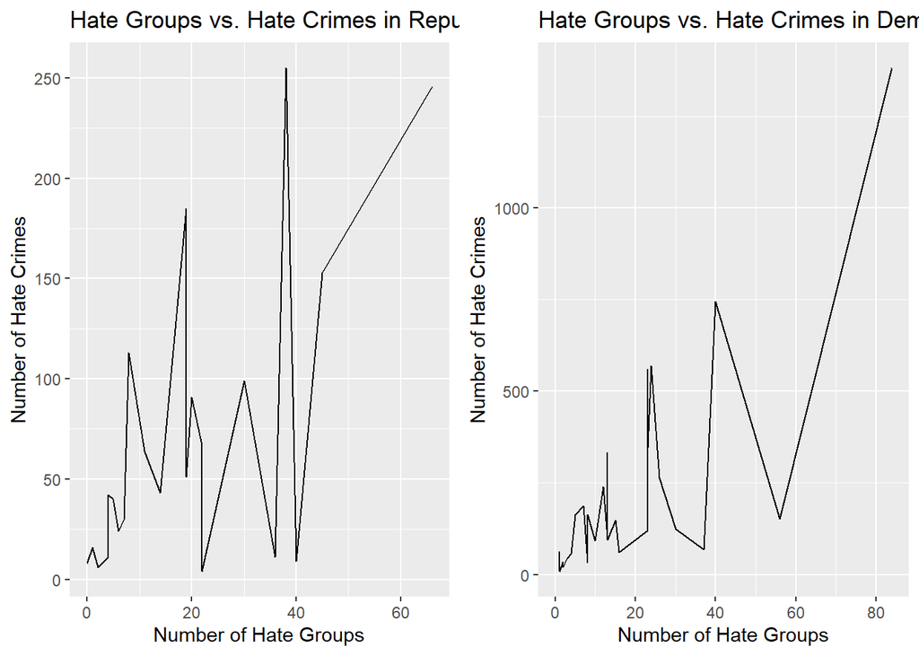

**Lineplot showing the relationship between hate groups and hate crimes for states that voted Republican in 2012.**

```
##  [1] "Alabama"        "Alaska"         "Arizona"        "Arkansas"
##  [5] "Georgia"        "Idaho"          "Indiana"        "Kansas"
##  [9] "Kentucky"       "Louisiana"      "Mississippi"    "Missouri"
## [13] "Montana"        "Nebraska"       "North Carolina" "North Dakota"
## [17] "Oklahoma"       "South Carolina" "South Dakota"   "Tennessee"
## [21] "Texas"          "Utah"           "West Virginia"  "Wyoming"
```

**Lineplot showing the relationship between hate groups and hate crimes for states that voted Democrat in 2012.**

```
##  [1] "California"    "Colorado"      "Connecticut"   "Delaware"
##  [5] "Florida"       "Hawaii"        "Illinois"      "Iowa"
##  [9] "Maine"         "Maryland"      "Massachusetts" "Michigan"
## [13] "Minnesota"     "Nevada"        "New Hampshire" "New Jersey"
## [17] "New Mexico"    "Ohio"          "Oregon"        "Pennsylvania"
## [21] "Rhode Island"  "Vermont"       "Virginia"      "Washington"
## [25] "Wisconsin"
```

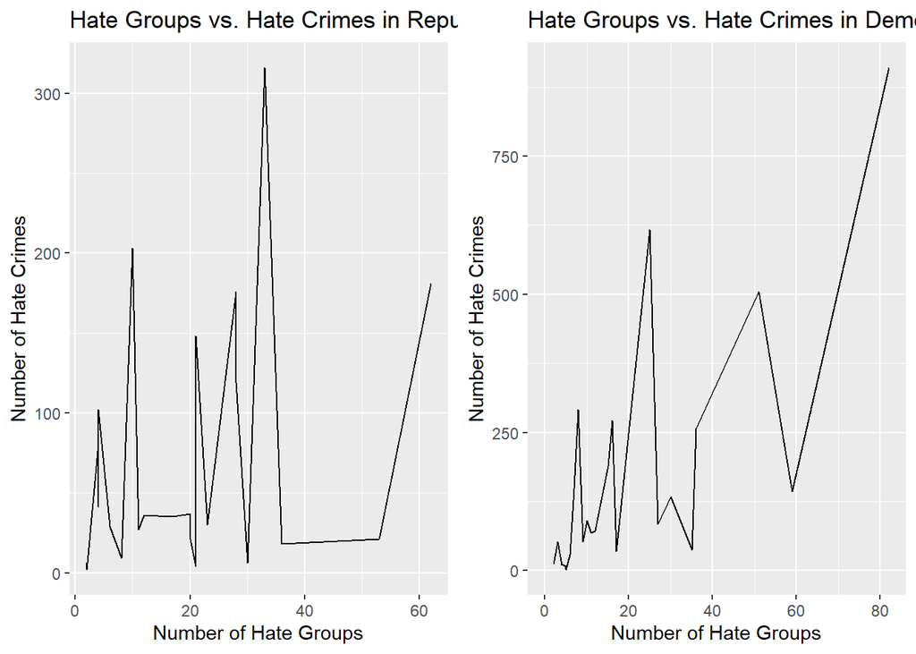

**Lineplot showing the relationship between hate groups and hate crimes for states that voted Republican in 2016.**

```
##  [1] "Alabama"        "Alaska"         "Arizona"        "Arkansas"
##  [5] "Florida"        "Georgia"        "Idaho"          "Indiana"
##  [9] "Iowa"           "Kansas"         "Kentucky"       "Louisiana"
## [13] "Michigan"       "Mississippi"    "Missouri"       "Montana"
## [17] "Nebraska"       "North Carolina" "North Dakota"   "Ohio"
## [21] "Oklahoma"       "Pennsylvania"   "South Carolina" "South Dakota"
## [25] "Tennessee"      "Texas"          "Utah"           "West Virginia"
## [29] "Wisconsin"      "Wyoming"
```

**Lineplot showing the relationship between hate groups and hate crimes for states that voted Democrat in 2016.**

```
##  [1] "California"    "Colorado"      "Connecticut"   "Delaware"
##  [5] "Hawaii"        "Illinois"      "Maine"         "Maryland"
##  [9] "Massachusetts" "Minnesota"     "Nevada"        "New Hampshire"
## [13] "New Jersey"    "New Mexico"    "New York"      "Oregon"
## [17] "Rhode Island"  "Vermont"       "Virginia"      "Washington"
```

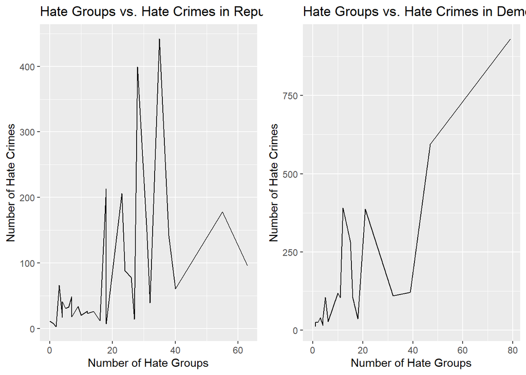

**Lineplot showing the relationship between hate groups and hate crimes for states that voted Republican in 2020.**

```
##  [1] "Alabama"        "Alaska"         "Arkansas"       "Florida"
##  [5] "Idaho"          "Indiana"        "Iowa"           "Kansas"
##  [9] "Kentucky"       "Louisiana"      "Mississippi"    "Missouri"
## [13] "Montana"        "Nebraska"       "North Carolina" "North Dakota"
## [17] "Ohio"           "Oklahoma"       "South Carolina" "South Dakota"
## [21] "Tennessee"      "Texas"          "Utah"           "West Virginia"
## [25] "Wyoming"
```

**Lineplot showing the relationship between hate groups and hate crimes for states that voted Democrat in 2020.**

```
##  [1] "Arizona"       "California"    "Colorado"      "Connecticut"
##  [5] "Delaware"      "Georgia"       "Hawaii"        "Illinois"
##  [9] "Maine"         "Maryland"      "Massachusetts" "Michigan"
## [13] "Minnesota"     "Nevada"        "New Hampshire" "New Jersey"
## [17] "New Mexico"    "New York"      "Oregon"        "Pennsylvania"
## [21] "Rhode Island"  "Vermont"       "Virginia"      "Washington"
## [25] "Wisconsin"
```

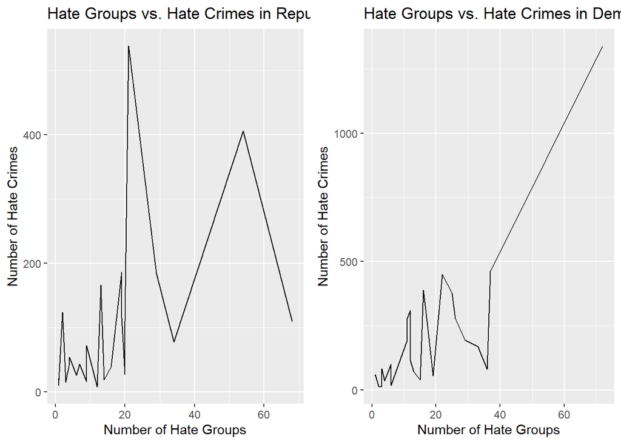

**Data Visualization Number Two: Scatterplots.**

**To accomplish this, we used the same parameters as for the lineplots, and simply switched out scatterplots for lineplots.**

**Scatterplot showing the relationship between hate groups and hate crimes for states that voted Republican in 2000.**

**Scatterplot showing the relationship between hate groups and hate crimes for states that voted Democrat in 2000.**

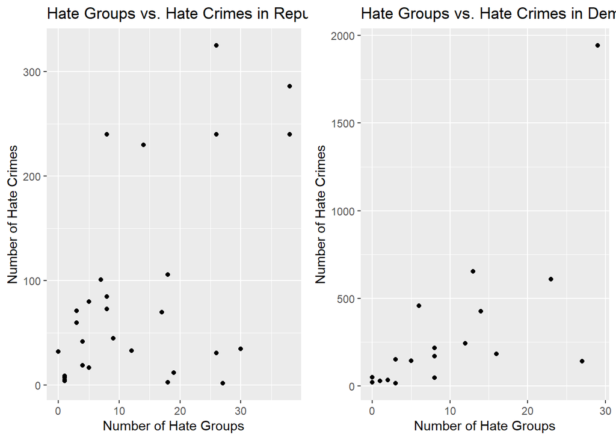

**Scatterplot showing the relationship between hate groups and hate crimes for states that voted Republican in 2004.**

**Scatterplot showing the relationship between hate groups and hate crimes for states that voted Democrat in 2004.**

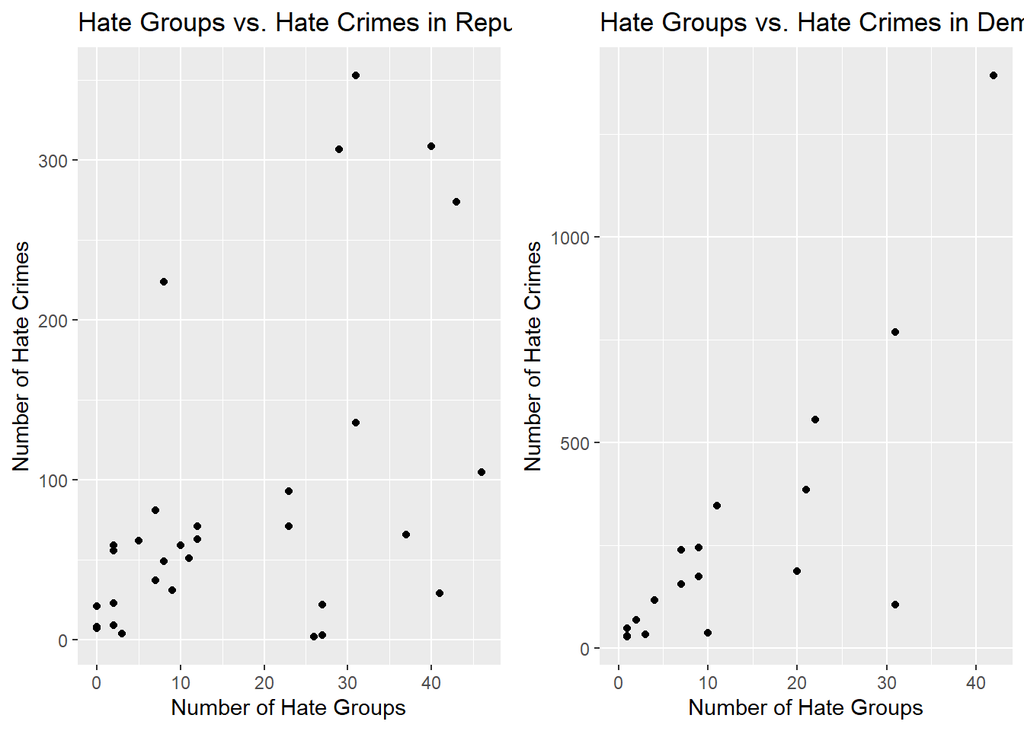

Looking at this second scatterplot for the year 2004, we once again have Republican states on the left and Democratic states on the right. We can see that there is a very even division in the steepness of slopes for both sets of states. Both sets of states seem to have a similar positive slope which means that there is no true split. Once again, political preference is not an impactful factor in this analysis, and no real conclusions can be drawn off this scatterplot. This plot fails to give us necessary evidence to disprove the null hypothesis.

**Scatterplot showing the relationship between hate groups and hate crimes for states that voted Republican in 2008.**

**Scatterplot showing the relationship between hate groups and hate crimes for states that voted Democrat in 2008.**

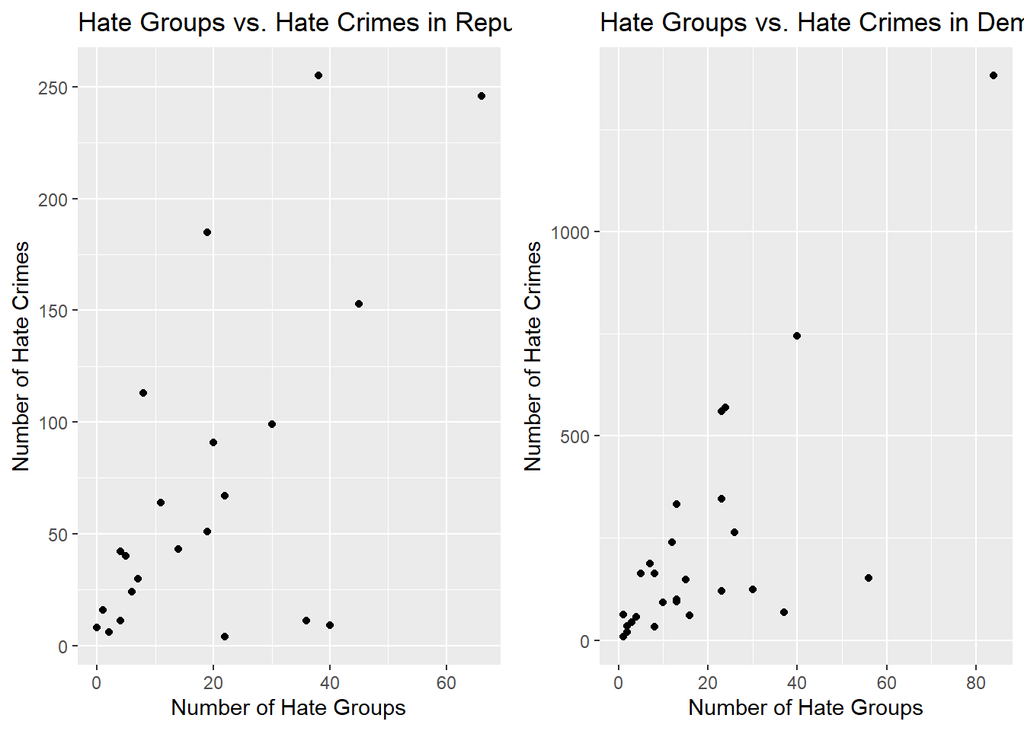

Looking at this third scatterplot for the year 2008, we once again have Republican states on the left and Democratic states on the right. Again, We can see that there is a very even division in the steepness of slopes for both sets of states. Both sets of states seem to have a similar positive slope which means that there is no true split. The Republican states do seem to have a few outliers towards the top of the left plot which may skew the slope a bit. Despite this, there are no blatently obvious trends which prove to be visual evidence that Republican states are more dangerous in terms of hate crimes than Democratic states. **Scatterplot showing the relationship between hate groups and hate crimes for states that voted Republican in 2012.**

**Scatterplot showing the relationship between hate groups and hate crimes for states that voted Democrat in 2012.**

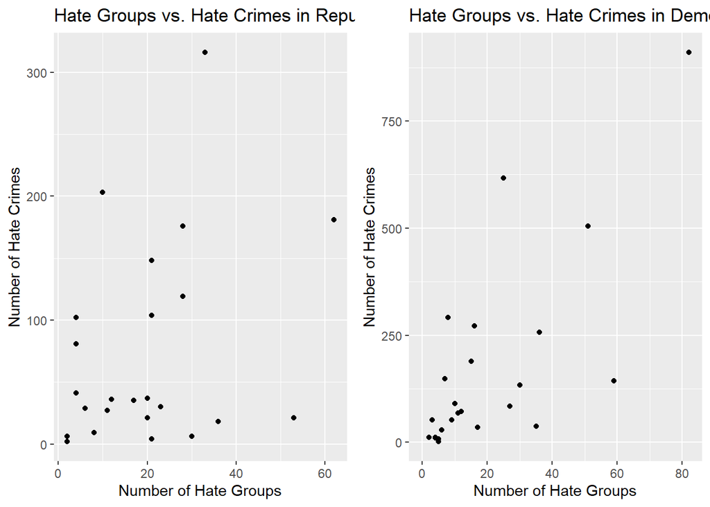

Looking at this fourth scatterplot for the year 2012, we once again have Republican states on the left and Democratic states on the right. This time, we see that the Republican states on the left do not have as strong a correlation as the Democratic states on the right. Specifically, the observations for the Republican states are less centralized and more spread out across the list. While this does not serve as enough information to reject the null hypothesis. One interesting note is that 2012 marks the first year in our data, accounting for election years, that Democratic states seem to have a stronger correlation between hate group numbers and hate crime figures.

**Scatterplot showing the relationship between hate groups and hate crimes for states that voted Republican in 2016.**

**Scatterplot showing the relationship between hate groups and hate crimes for states that voted Democrat in 2016.**

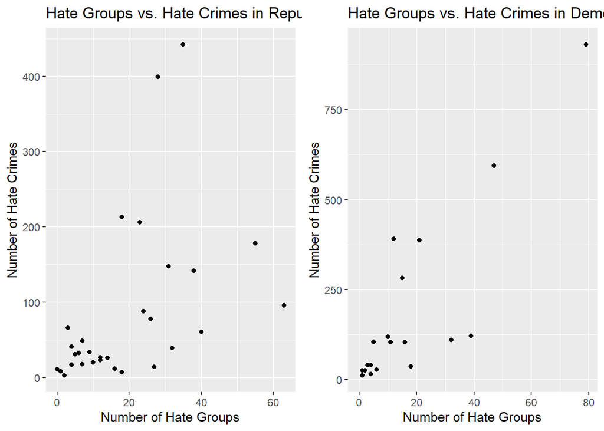

Looking at this fifth scatterplot for the year 2016, we once again have Republican states on the left and Democratic states on the right. We see that the Republican states on the left do not have as strong a correlation as the Democratic states on the right. Specifically, the observations for the Republican states are less centralized and more spread out across the list. There is also a faint trace of heteroscedasticity in both models which could mean that there is some error. The correlations here are not fully robust but they are generally positive for both sets of states. This does not serve as enough information to reject the null hypothesis.

**Scatterplot showing the relationship between hate groups and hate crimes for states that voted Republican in 2020.**

**Scatterplot showing the relationship between hate groups and hate crimes for states that voted Democrat in 2020.**

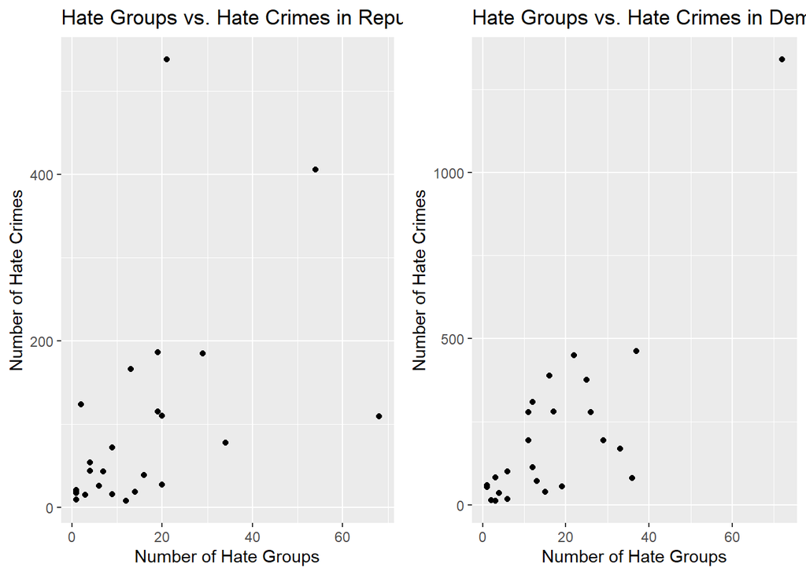

The sixth and final scatterplot for the year 2020 once again has Republican states on the left and Democratic states on the right. The Democratic states contain a stronger positive correlation than the Republican states. The Democratic states do however have a slight trace of heteroscedasticity which could mean that this plot is corrupted statistically. Ultimately, the correlations here are not fully robust but they are generally positive for both sets of states. These scatterplots do not serve as enough information to reject the null hypothesis.

# Section Five: Conclusions

The data visualizations proved to be a mixed bag. Both the lineplots and scatterplots occassionally favored either Republican or Democratic states as being safer, but no causal relationship can be drawn from these graphs. Additionally, the regression analysis shows that political partisanship does not greatly impact whether a certain set of states will receive higher hate crime rates than others. The trends displayed in these visualizations is a starting point, but each of these states must be examined in a thorough manner to determine the true cause of spikes in hate group presence and hate crime occurrence.

Our data also contained limitations which impacted this study. While the data from the Southern Poverty Law Center and U.S. Department of Justice contained all forms of hate groups and hate crimes, neither source further broke down the data by ethnic group. Therefore, we had to examine the data on a state by state level rather than on a more regional level. The impact of this is that it limited how closely we could study the data. For example, is Los Angeles more prone to hate crimes than San Diego despite them being only 100 miles apart and in the same state? Furthermore, does regional partisanship play more of a role in the occurrence of hate crimes than state-level partisanship? These are the types of questions we will look to examine in further iterations of this study.

Ultimately, we are unable to reject the null hypothesis with our findings in this study. We have greatly enjoyed researching this topic, and are eager to obtain more data and information to reject the null hypothesis in the future.

# Section Six: Data Bibliography

1. Unknown, Author. “Hate Map.” Southern Poverty Law Center, 15 Mar. 2023, https://www.splcenter.org/hate-map.
2. Unknown, Author. “Electoral College Results.” National Archives and Records Administration, National Archives and Records Administration, 16 Apr. 2021, https://www.archives.gov/electoral-college/results.
3. Unknown, Author. “Final 2021 State by State Incident Report 2021-2000.” ADL.org, Anti-Defamation League, 2022, https://www.adl.org/sites/default/files/pdfs/2022-12/Final%202021%20State%20by%20State%20Incident%20Report%202021-2000.pdf.